# Introduction

# Maroc Aircrafts types

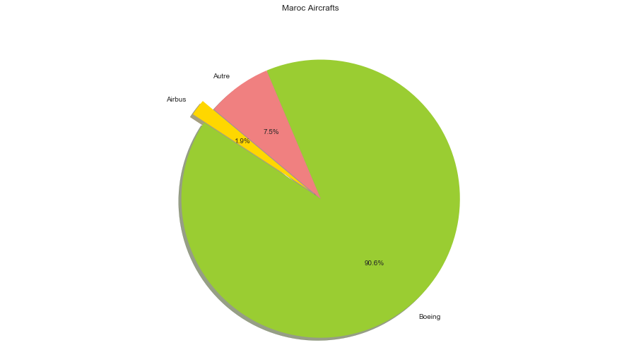

```python
labels = 'Airbus', 'Boeing', 'Autre'
sizes = [len(airm),len(boem),len(autresm)]
colors = ['gold', 'yellowgreen', 'lightcoral', 'lightskyblue']
explode = (0.1, 0, 0)  # explode 1st slice

fig = plt.figure(figsize=(16,8))
fig.suptitle('Maroc Aircrafts')
# Plot
plt.pie(sizes, explode=explode, labels=labels, colors=colors,
        autopct='%1.1f%%', shadow=True, startangle=140)

plt.axis('equal')
plt.show()
```

```python
aire=[]
boee=[]
autrese=[]
for index, row in egypt.iterrows():
        if("Airbus" in row['AircraftType']):
            aire.append(row['AircraftType'])
        elif("Boeing" in row['AircraftType']):
            boee.append(row['AircraftType'])
        else:
            autrese.append(row['AircraftType'])
```

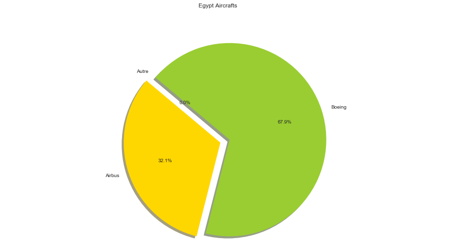

```python
labels = 'Airbus', 'Boeing', 'Autre'
sizes = [len(aire),len(boee),len(autrese)]
colors = ['gold', 'yellowgreen', 'lightcoral', 'lightskyblue']
explode = (0.1, 0, 0)  # explode 1st slice

fig = plt.figure(figsize=(16,8))
fig.suptitle('Egypt Aircrafts')
# Plot
plt.pie(sizes, explode=explode, labels=labels, colors=colors,
        autopct='%1.1f%%', shadow=True, startangle=140)

plt.axis('equal')
plt.show()
```

```python
airs=[]
boes=[]
autress=[]
for index, row in SouthAfricanAirways.iterrows():
        if("Airbus" in row['AircraftType']):
            airs.append(row['AircraftType'])
        elif("Boeing" in row['AircraftType']):
            boes.append(row['AircraftType'])
        else:
            autress.append(row['AircraftType'])
```

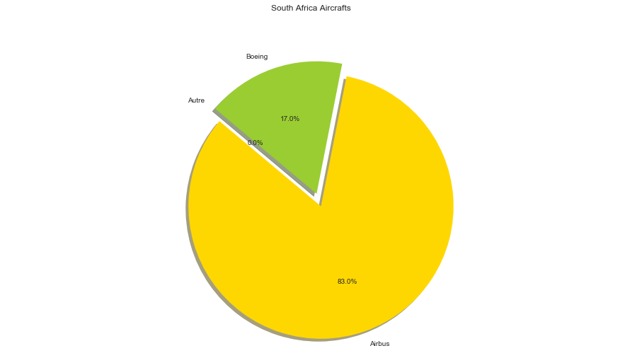

```python
labels = 'Airbus', 'Boeing', 'Autre'
sizes = [len(airs),len(boes),len(autress)]
colors = ['gold', 'yellowgreen', 'lightcoral', 'lightskyblue']
explode = (0.1, 0, 0)  # explode 1st slice

fig = plt.figure(figsize=(16,8))
fig.suptitle('South Africa Aircrafts')
# Plot
plt.pie(sizes, explode=explode, labels=labels, colors=colors,
        autopct='%1.1f%%', shadow=True, startangle=140)

plt.axis('equal')
plt.show()
```

```python
al=pd.read_csv('C:\\Users\Sedki\Desktop\Etude de la flotte Tunisair\\allAirPlanes.csv')
al['Class'].unique()
```

```
array(['LHBusiness', 'LHEconomy', 'LHFirst', 'PremiumEconomy', 'SHEconomy',
       'SHFirstBusiness'], dtype=object)
```

```python
delta=pd.read_csv('C:\\Users\Sedki\Desktop\Etude de la flotte Tunisair\\delta.csv')
```

```python
al['Class'].unique()
```

```
array(['LHBusiness', 'LHEconomy', 'LHFirst', 'PremiumEconomy',
       'SHEconomy', 'SHFirstBusiness'], dtype=object)
```

# 3-Data preparation

```python
tt=fleet.loc[fleet['Parent Airline'] == "Tunisair"]

tt
```

|  | Parent Airline | Airline | Aircraft Type | Current | Future | Historic | Total | Orders | Unit Cost | Total Cost (Current) | Average Age |
| --- | --- | --- | --- | --- | --- | --- | --- | --- | --- | --- | --- |
| 1468 | Tunisair | Tunisair | Airbus A300 | NaN | NaN | 7.0 | 7.0 | NaN | $75 | $0 | NaN |
| 1469 | Tunisair | Tunisair | Airbus A310 | NaN | NaN | 2.0 | 2.0 | NaN | $75 | $0 | NaN |
| 1470 | Tunisair | Tunisair | Airbus A319 | 4.0 | NaN | NaN | 4.0 | NaN | $90 | $358 | 15.5 |
| 1471 | Tunisair | Tunisair | Airbus A320 | 17.0 | NaN | 3.0 | 20.0 | 4.0 | $98 | $1,666 | 15.7 |
| 1472 | Tunisair | Tunisair | Airbus A330 | 2.0 | NaN | NaN | 2.0 | NaN | $240 | $480 | 1.7 |
| 1473 | Tunisair | Tunisair Express | ATR 42/72 | 3.0 | NaN | 1.0 | 4.0 | NaN | $22 | $66 | 14.2 |
| 1474 | Tunisair | Tunisair | Boeing 727 | NaN | NaN | 1.0 | 1.0 | NaN | $4 | $0 | NaN |
| 1475 | Tunisair | Tunisair | Boeing 737 | 7.0 | NaN | 25.0 | 32.0 | NaN | $74 | $518 | 16.9 |
| 1476 | Tunisair | Tunisair | Boeing 747 | NaN | NaN | 1.0 | 1.0 | NaN | $316 | $0 | NaN |
| 1477 | Tunisair | Tunisair Express | Canadair CRJ-900 | 1.0 | NaN | NaN | 1.0 | NaN | $46 | $46 | 10.2 |
| 1478 | Tunisair | Tunisair | McDonnell Douglas DC-10 | NaN | NaN | 2.0 | 2.0 | NaN | $145 | $0 | NaN |
| 1479 | Tunisair | Tunisair | McDonnell Douglas DC-8 | NaN | NaN | 2.0 | 2.0 | NaN | $6 | $0 | NaN |
| 1480 | Tunisair | Tunisair | McDonnell Douglas MD-90 | NaN | NaN | 1.0 | 1.0 | NaN | $45 | $0 | NaN |

reformating the coloumn price :

```python
tt=dd.loc[dd['Airline'] == "tunisair"]
tt.head()
```

|  | Reg | AircraftType | config | delivered | Age | Airline | price |
| --- | --- | --- | --- | --- | --- | --- | --- |
| 1468 | TS-IMJ | Airbus A319-100 | Y144 | Aug 1998 | 19.6 | tunisair | 90 |
| 1469 | TS-IMK | Airbus A319-100 | Y144 | Sep 1998 | 19.5 | tunisair | 90 |
| 1470 | TS-IMO | Airbus A319-100 | C16Y90 | Apr 2001 | 16.9 | tunisair | 90 |
| 1471 | TS-IMQ | Airbus A319-100 | C16Y90 | Apr 2007 | 10.8 | tunisair | 90 |
| 1472 | TS-IMC | Airbus A320-200 | CY162 | Nov 1990 | 27.5 | tunisair | 98 |

```python
dd["price"]=dd["price"].apply(lambda x:x.replace('$','') )
dd["Age"]=dd["Age"].apply(lambda x:x.replace(' Years','') )
dd.head()
```

|  | Reg | AircraftType | config | delivered | Age | Airline | price |
| --- | --- | --- | --- | --- | --- | --- | --- |
| 0 | HS-PGN | Airbus A319-132 | Y144 | 23. Jan 2009 | 9.1 | BangkokAirways | 90 |
| 1 | HS-PGT | Airbus A319-132 | Y144 | 05. Mar 2008 | 10.0 | BangkokAirways | 90 |
| 2 | HS-PGX | Airbus A319-132 | Y144 | 10. Mar 2008 | 10.0 | BangkokAirways | 90 |
| 3 | HS-PGY | Airbus A319-132 | Y144 | 07. Apr 2008 | 9.9 | BangkokAirways | 90 |
| 4 | HS-PGZ | Airbus A319-132 | Y144 | 13. Nov 2008 | 9.3 | BangkokAirways | 90 |

```python
from sklearn.cluster import KMeans
```

```python
clusterer = KMeans(n_clusters=3, random_state=10)
cluster_labels = clusterer.fit_predict(delta.loc[:,'Seat Width (First Class)':'Economy'])
delta.columns
```

```
Index(['Aircraft', 'Seat Width (Club)', 'Seat Pitch (Club)', 'Seat (Club)',
       'Seat Width (First Class)', 'Seat Pitch (First Class)',
       'Seats (First Class)', 'Seat Width (Business)', 'Seat Pitch (Business)',
       'Seats (Business)', 'Seat Width (Eco Comfort)',
       'Seat Pitch (Eco Comfort)', 'Seats (Eco Comfort)',
       'Seat Width (Economy)', 'Seat Pitch (Economy)', 'Seats (Economy)',
       'Accommodation', 'Cruising Speed (mph)', 'Range (miles)', 'Engines',
       'Wingspan (ft)', 'Tail Height (ft)', 'Length (ft)', 'Wifi', 'Video',
       'Power', 'Satellite', 'Flat-bed', 'Sleeper', 'Club', 'First Class',
       'Business', 'Eco Comfort', 'Economy', 'Class'],
      dtype='object')
```

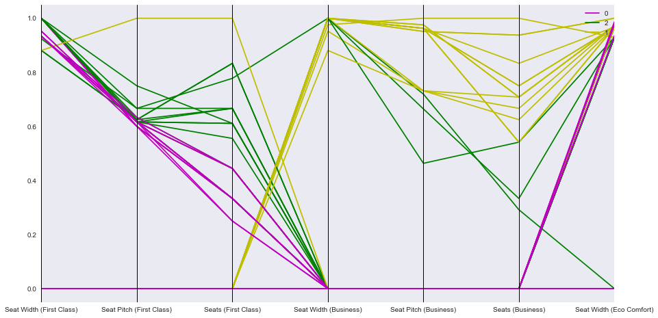

```python
from pandas.plotting import parallel_coordinates

#clusterer = KMeans(n_clusters=2, random_state=10)
x = delta.loc[:,'Seat Width (First Class)':'Seat Width (Eco Comfort)']
x.columns=[ 'Seat Width (First Class)','Seat Pitch (First Class)','Seats (First Class)','Seat Width (Business)',
           'Seat Pitch (Business)','Seats (Business)','Seat Width (Eco Comfort)']
delta['cluster']=cluster_labels
y=delta["cluster"]

X_norm = (x - x.min())/(x.max() - x.min())
# Select features to include in the plot
plot_feat = ['Seat Width (First Class)','Seat Pitch (First Class)','Seats (First Class)','Seat Width (Business)',
           'Seat Pitch (Business)','Seats (Business)','Seat Width (Eco Comfort)']
# Concat classes with the normalized data
data_norm = pd.concat([X_norm[plot_feat], y], axis=1)
plt.figure(figsize=(15,8))
# Perform parallel coordinate plot
parallel_coordinates(data_norm, 'cluster',color=['m','g','y'])
plt.show()
```

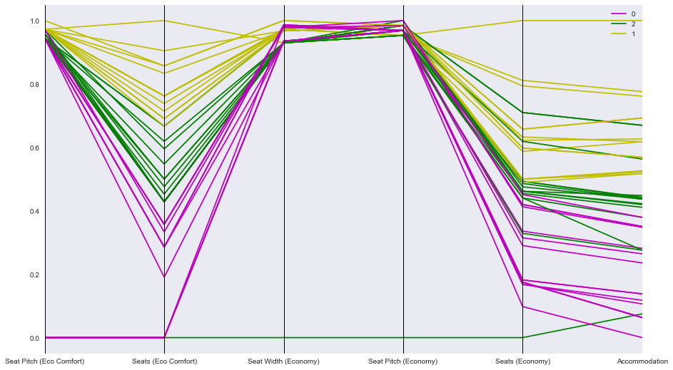

```python
x = delta.loc[:,'Seat Pitch (Eco Comfort)':'Accommodation']
x.columns=['Seat Pitch (Eco Comfort)', 'Seats (Eco Comfort)',
       'Seat Width (Economy)', 'Seat Pitch (Economy)', 'Seats (Economy)',
       'Accommodation']
delta['cluster']=cluster_labels
y=delta["cluster"]

X_norm = (x - x.min())/(x.max() - x.min())
# Select features to include in the plot
plot_feat = ['Seat Pitch (Eco Comfort)', 'Seats (Eco Comfort)',
       'Seat Width (Economy)', 'Seat Pitch (Economy)', 'Seats (Economy)',
       'Accommodation']
# Concat classes with the normalized data
data_norm = pd.concat([X_norm[plot_feat], y], axis=1)
plt.figure(figsize=(15,9))
# Perform parallel coordinate plot
parallel_coordinates(data_norm, 'cluster',color=['m','g','y'])
plt.show()
```

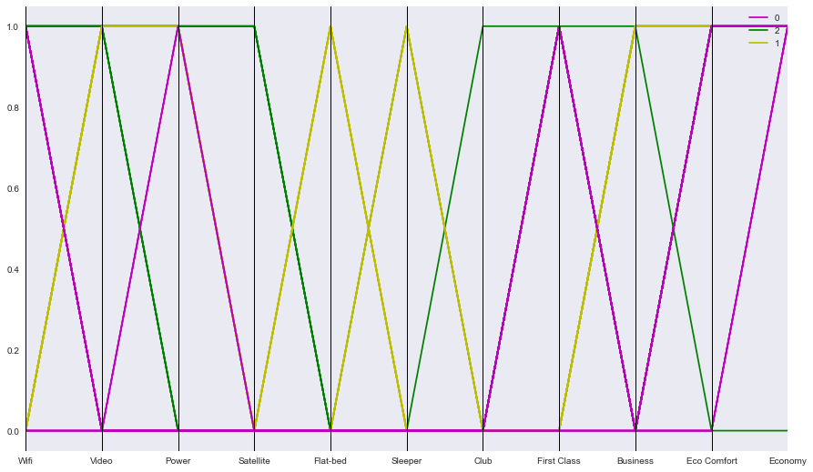

```python
x = delta.loc[:,'Wifi':'Economy']
x.columns=[ 'Wifi', 'Video',
       'Power', 'Satellite', 'Flat-bed', 'Sleeper', 'Club', 'First Class',
       'Business', 'Eco Comfort', 'Economy']
delta['cluster']=cluster_labels
y=delta["cluster"]

X_norm = (x - x.min())/(x.max() - x.min())
# Select features to include in the plot
plot_feat = ['Wifi', 'Video',
       'Power', 'Satellite', 'Flat-bed', 'Sleeper', 'Club', 'First Class',
       'Business', 'Eco Comfort', 'Economy']
# Concat classes with the normalized data
data_norm = pd.concat([X_norm[plot_feat], y], axis=1)
plt.figure(figsize=(15,9))
# Perform parallel coordinate plot
parallel_coordinates(data_norm, 'cluster',color=['m','g','y'])
plt.show()
```

```python
test=delta[delta['cluster']==2]
len(test)
```

```
15
```

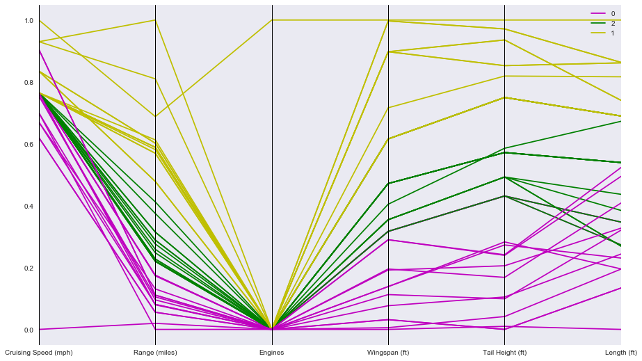

```python
x = delta.loc[:,'Cruising Speed (mph)':'Length (ft)']
x.columns=['Cruising Speed (mph)', 'Range (miles)', 'Engines',
       'Wingspan (ft)', 'Tail Height (ft)', 'Length (ft)']
delta['cluster']=cluster_labels
y=delta["cluster"]

X_norm = (x - x.min())/(x.max() - x.min())
# Select features to include in the plot
plot_feat = ['Cruising Speed (mph)', 'Range (miles)', 'Engines',
       'Wingspan (ft)', 'Tail Height (ft)', 'Length (ft)']
# Concat classes with the normalized data
data_norm = pd.concat([X_norm[plot_feat], y], axis=1)
plt.figure(figsize=(15,9))
# Perform parallel coordinate plot
parallel_coordinates(data_norm, 'cluster',color=['m','g','y'])
plt.show()
```

```python
cl0=delta[delta['cluster']==0]
print('cl0')
cl0.Aircraft
```

```
cl0
```

```
0                      Airbus A319
2                      Airbus A320
3                 Airbus A320 32-R
8                       Boeing 717
33    CRJ 100/200 Pinnacle/SkyWest
34          CRJ 100/200 ExpressJet
35                         CRJ 700
36                         CRJ 900
37                            E120
38                            E170
39                            E175
40                         ERJ-145
41                           MD-88
42                           MD-90
43                       MD-DC9-50
Name: Aircraft, dtype: object
```

```python
cl1=delta[delta['cluster']==1]
print('cl1')
cl1.Aircraft
```

```
cl1
```

```
4              Airbus A330-200
5        Airbus A330-200 (3L2)
6        Airbus A330-200 (3L3)
7              Airbus A330-300
13        Boeing 747-400 (74S)
22        Boeing 767-300 (76G)
23        Boeing 767-300 (76L)
26        Boeing 767-300 (76T)
27        Boeing 767-300 (76U)
28    Boeing 767-300 (76Z V.1)
29    Boeing 767-300 (76Z V.2)
30        Boeing 767-400 (76D)
31            Boeing 777-200ER
32            Boeing 777-200LR
Name: Aircraft, dtype: object
```

```python
cl2=delta[delta['cluster']==2]
print('cl2')
cl2.Aircraft
```

```
cl2
```

```
1            Airbus A319 VIP
9       Boeing 737-700 (73W)
10      Boeing 737-800 (738)
11      Boeing 737-800 (73H)
12    Boeing 737-900ER (739)
14      Boeing 757-200 (75A)
15      Boeing 757-200 (75E)
16      Boeing 757-200 (75M)
17      Boeing 757-200 (75N)
18      Boeing 757-200 (757)
19      Boeing 757-200 (75V)
20      Boeing 757-200 (75X)
21            Boeing 757-300
24      Boeing 767-300 (76P)
25      Boeing 767-300 (76Q)
Name: Aircraft, dtype: object
```

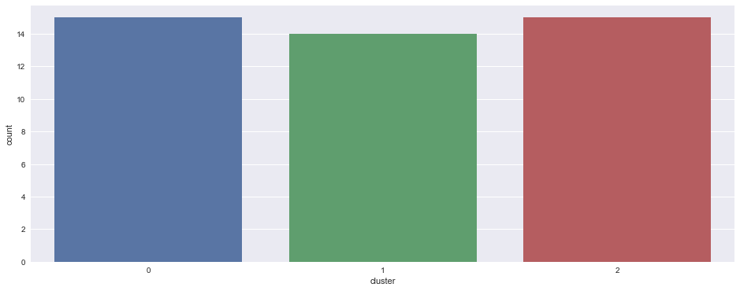

```python
fig = plt.figure(figsize=(16,6))
ax = sns.countplot(x='cluster',data=delta)
```

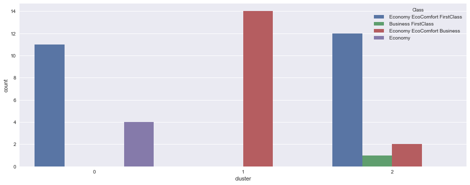

```python
fig = plt.figure(figsize=(16,6))
ax = sns.countplot(x='cluster',hue='Class',data=delta)
```

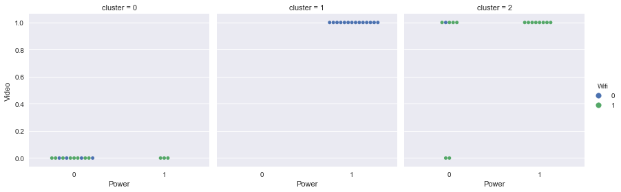

```python
plt.figure(figsize=(14, 8))
g = sns.factorplot("Power", "Video", "Wifi", col="cluster", data=delta, kind="swarm")
```

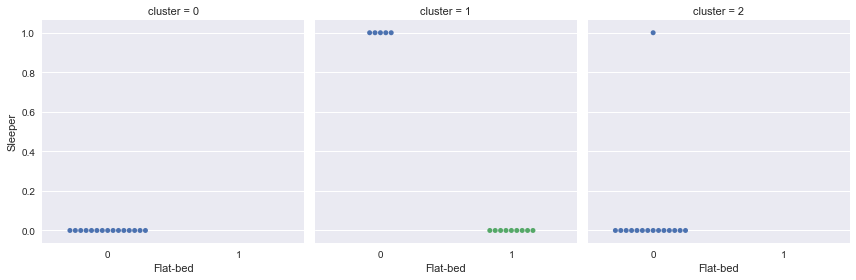

```python
plt.figure(figsize=(14, 8))
g = sns.factorplot("Flat-bed", "Sleeper", col="cluster", data=delta, kind="swarm")
```

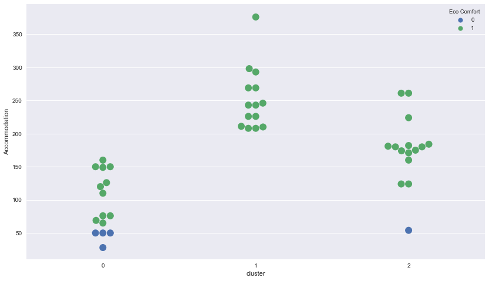

```python
plt.figure(figsize=(14, 8))

sns.swarmplot(x="cluster", y="Accommodation",hue="Eco Comfort", data=delta,size=12);
```

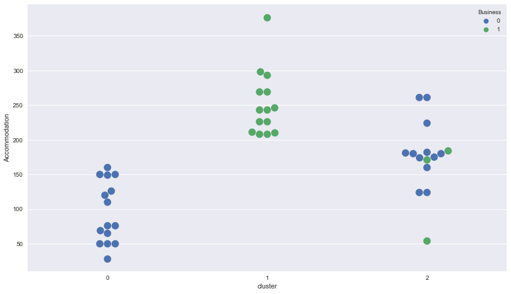

```python
plt.figure(figsize=(14, 8))

sns.swarmplot(x="cluster", y="Accommodation",hue="Business", data=delta,size=12);
```

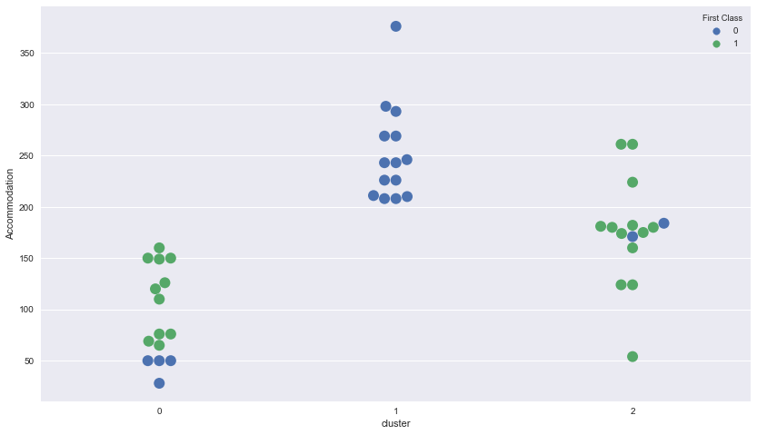

```python
plt.figure(figsize=(14, 8))

sns.swarmplot(x="cluster", y="Accommodation",hue="First Class", data=delta,size=12);
```

```python
c1=delta.loc[delta['Class'] ==' Economy EcoComfort FirstClass' ]
c2=delta.loc[delta['Class'] ==' Business FirstClass' ]
c3=delta.loc[delta['Class'] ==' Economy EcoComfort Business' ]
c4=delta.loc[delta['Class'] ==' Economy' ]

cluster1=delta.loc[delta['cluster'] == 0 ]
cluster2=delta.loc[delta['cluster'] == 1 ]
cluster3=delta.loc[delta['cluster'] == 2 ]
```

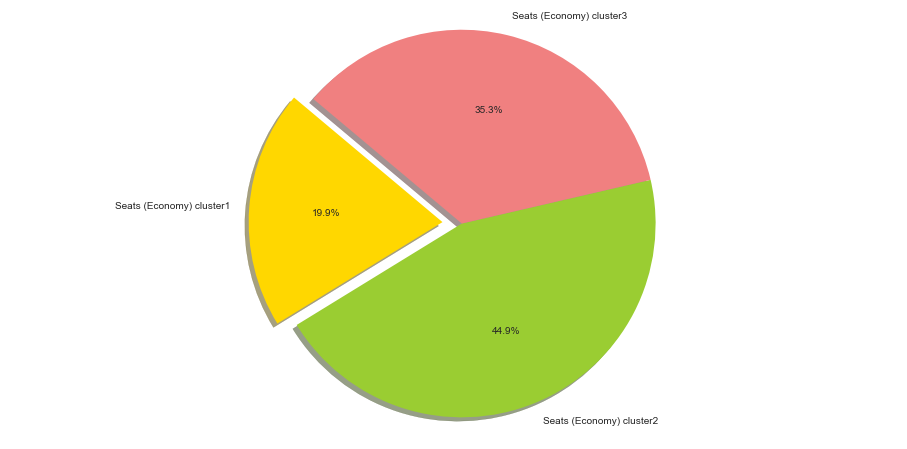

```python
e=cluster1['Seats (Economy)'].sum()
b=cluster2['Seats (Economy)'].sum()
com=cluster3['Seats (Economy)'].sum()


labels = 'Seats (Economy) cluster1', 'Seats (Economy) cluster2','Seats (Economy) cluster3'
sizes = [e,b,com]
colors = ['gold', 'yellowgreen', 'lightcoral', 'lightskyblue']
explode = (0.1, 0,0)  # explode 1st slice
fig = plt.figure(figsize=(16,8))
# Plot
plt.pie(sizes, explode=explode, labels=labels, colors=colors,
        autopct='%1.1f%%', shadow=True, startangle=140)

plt.axis('equal')
plt.show()
```

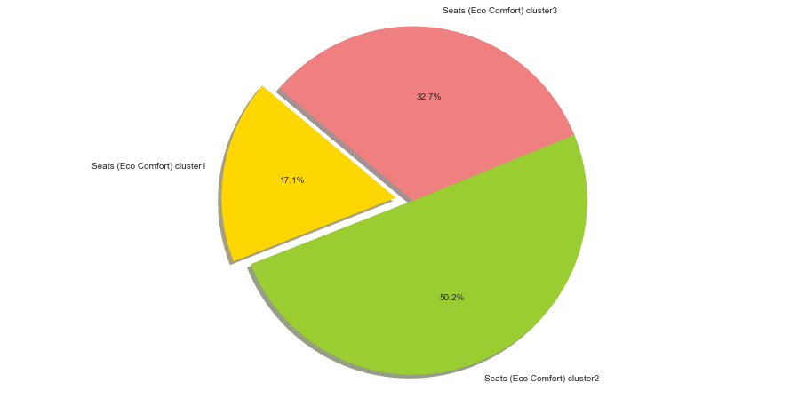

```python
e=cluster1['Seats (Eco Comfort)'].sum()
b=cluster2['Seats (Eco Comfort)'].sum()
com=cluster3['Seats (Eco Comfort)'].sum()


labels = 'Seats (Eco Comfort) cluster1', 'Seats (Eco Comfort) cluster2','Seats (Eco Comfort) cluster3'
sizes = [e,b,com]
colors = ['gold', 'yellowgreen', 'lightcoral', 'lightskyblue']
explode = (0.1, 0,0)  # explode 1st slice
fig = plt.figure(figsize=(16,8))

# Plot
plt.pie(sizes, explode=explode, labels=labels, colors=colors,
        autopct='%1.1f%%', shadow=True, startangle=140)

plt.axis('equal')
plt.show()
```

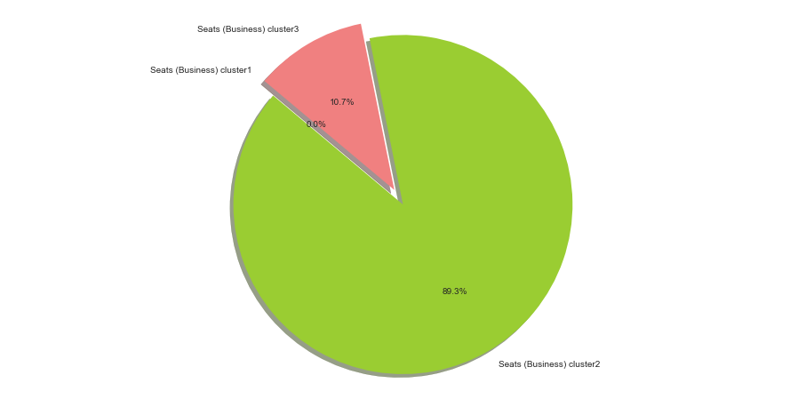

```python
e=cluster1['Seats (Business)'].sum()
b=cluster2['Seats (Business)'].sum()
com=cluster3['Seats (Business)'].sum()


labels = 'Seats (Business) cluster1', 'Seats (Business) cluster2','Seats (Business) cluster3'
sizes = [e,b,com]
colors = ['gold', 'yellowgreen', 'lightcoral', 'lightskyblue']
explode = (0, 0.1,0)  # explode 1st slice
fig = plt.figure(figsize=(16,8))

# Plot
plt.pie(sizes, explode=explode, labels=labels, colors=colors,
        autopct='%1.1f%%', shadow=True, startangle=140)

plt.axis('equal')
plt.show()
```

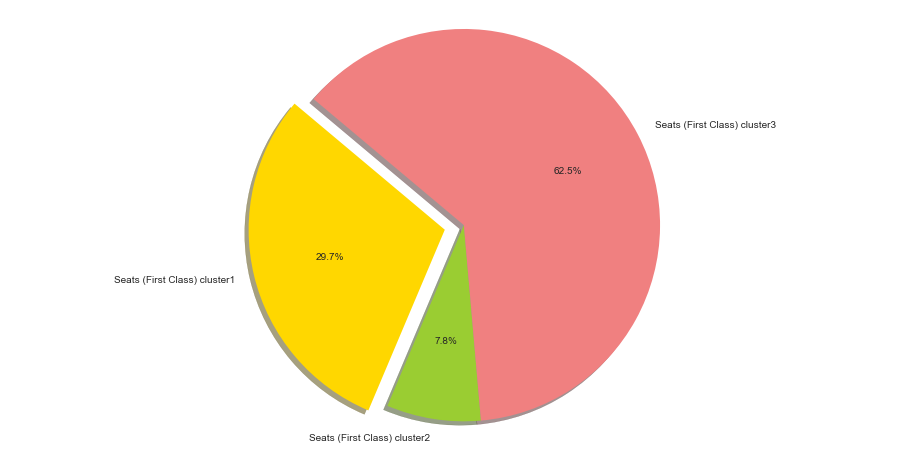

```python
e=cluster1['Seats (First Class)'].sum()
b=cluster2['Seats (First Class)'].sum()
com=cluster3['Seats (First Class)'].sum()


labels = 'Seats (First Class) cluster1', 'Seats (First Class) cluster2','Seats (First Class) cluster3'
sizes = [e,b,com]
colors = ['gold', 'yellowgreen', 'lightcoral', 'lightskyblue']
explode = (0.1, 0,0)  # explode 1st slice
fig = plt.figure(figsize=(16,8))

# Plot
plt.pie(sizes, explode=explode, labels=labels, colors=colors,
        autopct='%1.1f%%', shadow=True, startangle=140)

plt.axis('equal')
plt.show()
```

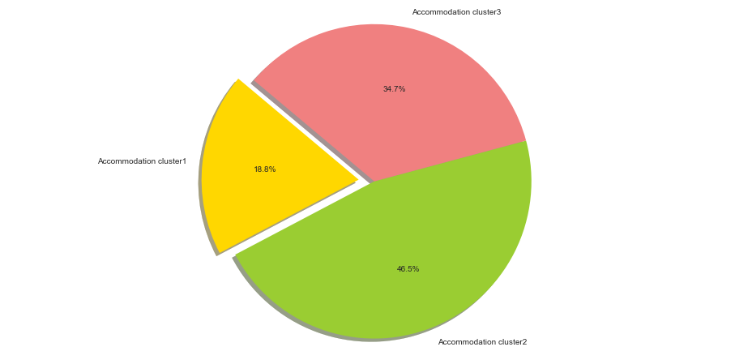

```python
e=cluster1['Accommodation'].sum()
b=cluster2['Accommodation'].sum()
com=cluster3['Accommodation'].sum()


labels = 'Accommodation cluster1', 'Accommodation cluster2','Accommodation cluster3'
sizes = [e,b,com]
colors = ['gold', 'yellowgreen', 'lightcoral', 'lightskyblue']
explode = (0.1, 0,0)  # explode 1st slice
fig = plt.figure(figsize=(16,8))

# Plot
plt.pie(sizes, explode=explode, labels=labels, colors=colors,
        autopct='%1.1f%%', shadow=True, startangle=140)

plt.axis('equal')
plt.show()
```

# Typical profile of aircrafts

# First cluster specifications:

> first class , eco-comfort class, economy class  
> small size aircraft  
> seats number isn’t high  
> wifi ,power  
> minimum length  
> Aircarfts with the lowest price comparing to the others with a gap of 25$ to 98$  
> lowest number of seats(economy)  
> lowest number of seats(eco confort)  
> no buisness seats  
> second highest number of seats(first class)  
> Here are some of the Aircrafts which belong to this cluster , we have :  
> 0 - Airbus A319  
> 2 - Airbus A320  
> 3 - Airbus A320 32-R  
> 8 - Boeing 717  
> 33 -CRJ 100/200 Pinnacle/SkyWest  
> 34 - CRJ 100/200 ExpressJet  
> 35 - CRJ 700  
> 36 - CRJ 900  
> 37 - E120  
> 38 - E170  
> 39 - E175  
> 40 -ERJ-145  
> 41 - MD-88  
> 42 - MD-90  
> this cluster stands for aircrafts that provide the basics of comfort but they are not overly luxurious

# Second cluster specifications:

> buisness class,eco comfort  
> dimension of seats  
> video,power  
> flat bed or sleeper(one of them)  
> very high price over '200'$'  
> longest aircrafts  
> highest number of seats(economy)  
> highest number of seats(eco confort)  
> highest number of seats(buisness)  
> lowest number of seats(first class)  
> Here are some of the Aircrafts which belong to this cluster , we have :  
> 4 - Airbus A330-200  
> 5 - Airbus A330-200 (3L2)  
> 6 - Airbus A330-200 (3L3)  
> 7 - Airbus A330-300  
> 13 -Boeing 747-400 (74S)  
> 22 - Boeing 767-300 (76G)  
> 23 Boeing 767-300 (76L)  
> 26 - Boeing 767-300 (76T)  
> 27 - Boeing 767-300 (76U)  
> 28 -Boeing 767-300 (76Z V.1)  
> 29 - Boeing 767-300 (76Z V.2)  
> 30 - Boeing 767-400 (76D)  
> 31 - Boeing 777-200ER  
> 32 - Boeing 777-200LR

this cluster stands for the aircrafcts with the highest price:  
the biggest aircrafts or luxurious aircrafts

# Third cluster specifications:

> first class ,eco comfort,economy,buisness wifi,video,satellite  
> club :only with business class  
> medium price over 100$  
> second lenght  
> second highest number of seats(economy)  
> second highest number of seats(eco comfort)  
> second highest number of seats(buisness)  
> highest number of seats(first class)  
> Here are some of the Aircrafts which belong to this cluster , we have :  
> 1 - Airbus A319 VIP  
> 9 -Boeing 737-700 (73W)  
> 10 - Boeing 737-800 (738)  
> 11 - Boeing 737-800 (73H)  
> 12 -Boeing 737-900ER (739)  
> 14 - Boeing 757-200 (75A)  
> 15 -Boeing 757-200 (75E)  
> 16 -Boeing 757-200 (75M)  
> 17 - Boeing 757-200 (75N)  
> 18 - Boeing 757-200 (757)  
> 19 - Boeing 757-200 (75V)  
> 20 - Boeing 757-200 (75X)  
> 21 - Boeing 757-300  
> 24 - Boeing 767-300 (76P)  
> 25 - Boeing 767-300 (76Q)  
> this cluster stands for aircrafts which contains every class (first class ,eco comfort,,economy,buisness)espacially for the first class

```python
delta.cluster.unique()
cl0=delta[delta.cluster==0]
cl0.mean()
```

```
Seat Width (Club)              0.000000
Seat Pitch (Club)              0.000000
Seat (Club)                    0.000000
Seat Width (First Class)      14.706667
Seat Pitch (First Class)      26.933333
Seats (First Class)            9.200000
Seat Width (Business)          0.000000
Seat Pitch (Business)          0.000000
Seats (Business)               0.000000
Seat Width (Eco Comfort)      13.006667
Seat Pitch (Eco Comfort)      25.000000
Seats (Eco Comfort)           10.466667
Seat Width (Economy)          17.680000
Seat Pitch (Economy)          31.133333
Seats (Economy)               75.600000
Accommodation                 95.266667
Cruising Speed (mph)         502.133333
Range (miles)               1661.466667
Engines                        2.000000
Wingspan (ft)                 89.120467
Tail Height (ft)              28.726867
Length (ft)                  111.843600
Wifi                           0.733333
Video                          0.000000
Power                          0.200000
Satellite                      0.000000
Flat-bed                       0.000000
Sleeper                        0.000000
Club                           0.000000
First Class                    0.733333
Business                       0.000000
Eco Comfort                    0.733333
Economy                        1.000000
cluster                        0.000000
dtype: float64
```

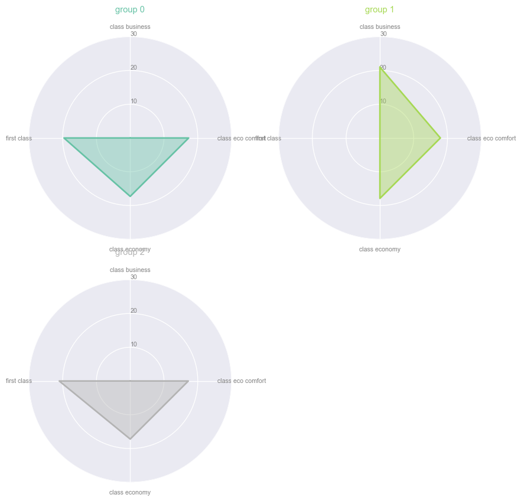

```python
from math import pi

cl0=delta[delta.cluster==0]
cl1=delta[delta.cluster==1]
cl2=delta[delta.cluster==2]

df = pd.DataFrame({
'cl': ["0","1","2"],
'class business': [cl0['Seat Width (Business)'].median(),cl1['Seat Width (Business)'].median(),cl2['Seat Width (Business)'].median()],
'class economy': [cl0['Seat Width (Economy)'].median(),cl1['Seat Width (Economy)'].median(),cl2['Seat Width (Economy)'].median()],
'first class': [cl0['Seat Width (First Class)'].median(),cl1['Seat Width (First Class)'].median(),
                cl2['Seat Width (First Class)'].median()],
'class eco comfort': [cl0['Seat Width (Eco Comfort)'].median(),cl1['Seat Width (Eco Comfort)'].median(),cl2['Seat Width (Eco Comfort)'].median() ]

})
#df.columns=['group','economy','business','first class','eco comfort']


# Set data


# ------- PART 1: Define a function that do a plot for one line of the dataset!

def make_spider( row, title, color):

    categories=list(df)[1:]
    N = len(categories)

    # What will be the angle of each axis in the plot? (we divide the plot / number of variable)
    angles = [n / float(N) * 2 * pi for n in range(N)]
    angles += angles[:1]

# Initialise the spider plot
    ax = plt.subplot(2,2,row+1, polar=True, )

# If you want the first axis to be on top:
    ax.set_theta_offset(pi / 2)
    ax.set_theta_direction(-1)

# Draw one axe per variable + add labels labels yet
    plt.xticks(angles[:-1], categories, color='grey', size=8)

# Draw ylabels
    ax.set_rlabel_position(0)
    plt.yticks([10,20,30], ["10","20","30"], color="grey", size=8)
    plt.ylim(0,30)

# Ind1
    values=df.loc[row].drop('cl').values.flatten().tolist()
    values += values[:1]
    ax.plot(angles, values, color=color, linewidth=2, linestyle='solid')
    ax.fill(angles, values, color=color, alpha=0.4)


# Add a title
    plt.title(title, size=11, color=color, y=1.1)

# ------- PART 2: Apply to all individuals
# initialize the figure
my_dpi=96
plt.figure(figsize=(1000/my_dpi, 1000/my_dpi), dpi=my_dpi)

# Create a color palette:
my_palette = plt.cm.get_cmap("Set2", len(df.index))

# Loop to plot
for row in range(0, len(df.index)):
    make_spider( row=row, title='group '+str(df['cl'][row]), color=my_palette(row))
```

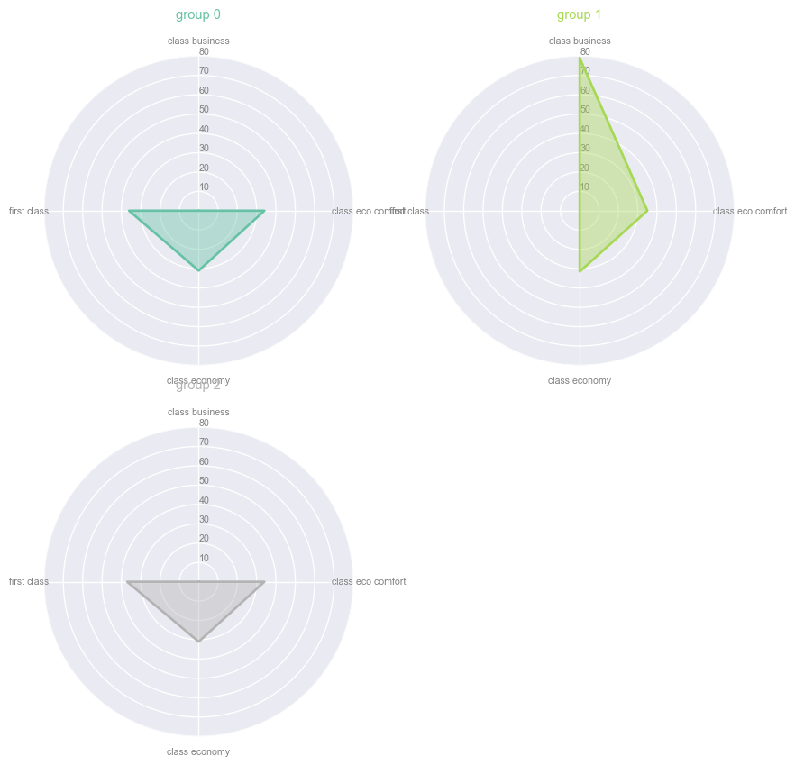

```python
df = pd.DataFrame({
'cl': ["0","1","2"],
'class business': [cl0['Seat Pitch (Business)'].median(),cl1['Seat Pitch (Business)'].median(),cl2['Seat Pitch (Business)'].median()],
'class economy': [cl0['Seat Pitch (Economy)'].median(),cl1['Seat Pitch (Economy)'].median(),cl2['Seat Pitch (Economy)'].median()],
'first class': [cl0['Seat Pitch (First Class)'].median(),cl1['Seat Pitch (First Class)'].median(),
                cl2['Seat Pitch (First Class)'].median()],
'class eco comfort': [cl0['Seat Pitch (Eco Comfort)'].median(),cl1['Seat Pitch (Eco Comfort)'].median(),cl2['Seat Pitch (Eco Comfort)'].median() ]

})
#df.columns=['group','economy','business','first class','eco comfort']


# Set data


# ------- PART 1: Define a function that do a plot for one line of the dataset!

def make_spider( row, title, color):

    categories=list(df)[1:]
    N = len(categories)

    # What will be the angle of each axis in the plot? (we divide the plot / number of variable)
    angles = [n / float(N) * 2 * pi for n in range(N)]
    angles += angles[:1]

# Initialise the spider plot
    ax = plt.subplot(2,2,row+1, polar=True, )

# If you want the first axis to be on top:
    ax.set_theta_offset(pi / 2)
    ax.set_theta_direction(-1)

# Draw one axe per variable + add labels labels yet
    plt.xticks(angles[:-1], categories, color='grey', size=8)

# Draw ylabels
    ax.set_rlabel_position(0)
    plt.yticks([10,20,30,40,50,60,70,80], ["10","20","30","40","50","60","70",80], color="grey", size=8)
    plt.ylim(0,80)

# Ind1
    values=df.loc[row].drop('cl').values.flatten().tolist()
    values += values[:1]
    ax.plot(angles, values, color=color, linewidth=2, linestyle='solid')
    ax.fill(angles, values, color=color, alpha=0.4)


# Add a title
    plt.title(title, size=11, color=color, y=1.1)

# ------- PART 2: Apply to all individuals
# initialize the figure
my_dpi=96
plt.figure(figsize=(1000/my_dpi, 1000/my_dpi), dpi=my_dpi)

# Create a color palette:
my_palette = plt.cm.get_cmap("Set2", len(df.index))

# Loop to plot
for row in range(0, len(df.index)):
    make_spider( row=row, title='group '+str(df['cl'][row]), color=my_palette(row))
```